# script

2026-11-16

#Primero cargamos los paquetes a usar y ordenar los indicadores socioeconomicoss que elegimos (ipc y desempleo) para poder hacer una base conjunta y calcular el promedio del indicador de 12 meses antes de la elección.

```r
library(readxl)
library(dplyr)
library(lubridate)
library(modelsummary)
library(survival)
```

```r
desempleo <- read_excel("data/desempleo.xlsx", skip = 2)
ipc <- read_excel("data/ipc.xlsx", skip = 2)

desempleo <- desempleo[, c(1, 5)]
names(desempleo) <- c("mes", "desempleo")

ipc <- ipc[, c(1, 2)]
names(ipc) <- c("mes", "ipc")
```

#Unir indicadores economicos

```r
desempleo$mes <- as.Date(desempleo$mes)
ipc$mes <- as.Date(ipc$mes)

economia <- left_join(desempleo, ipc, by = "mes")
```

#Crear tabla con las elecciones

```r
elecciones <- data.frame(
  eleccion = c(1989, 1993, 1993, 1999, 1999, 2005, 2005, 2009, 2009,
               2013, 2013, 2013, 2017, 2017, 2017, 2021, 2021, 2021, 2025, 2025, 2025),
  vuelta   = c("primera", "primaria", "primera", "primera", "segunda", "primera", "segunda", "primera", "segunda",
               "primaria", "primera", "segunda", "primaria", "primera", "segunda",
               "primaria", "primera", "segunda", "primaria", "primera", "segunda"),
  fecha    = as.Date(c("1989-12-14", "1993-05-23", "1993-12-11", "1999-12-12", "2000-01-16",
                       "2005-12-11", "2006-01-15", "2009-12-13", "2010-01-17",
                       "2013-06-30", "2013-11-17", "2013-12-15",
                       "2017-07-02", "2017-11-19", "2017-12-17",
                       "2021-07-18", "2021-11-21", "2021-12-19",
                       "2025-06-29", "2025-11-16", "2025-12-14"))
)
```

#Aca calculamos el promedio de los indicadores economicos que usamos de los 12 meses anteriories

```r
elecciones$desempleo <- NA
elecciones$ipc <- NA

for (i in 1:nrow(elecciones)) {
  mes_eleccion <- floor_date(elecciones$fecha[i], "month")
  ventana <- filter(economia, mes >= mes_eleccion - months(12), mes < mes_eleccion)
  elecciones$desempleo[i] <- round(mean(ventana$desempleo), 2)
  elecciones$ipc[i] <- round(mean(ventana$ipc), 2)
}
```

#Cargamos la base de esandalos y renombramos las columnas, tambien dejamos todos los nombres en minusculas para que sea mas facil

```r
escandalos <- read_excel("data/base.xlsx", sheet = "escandalos")

names(escandalos) <- c("anio", "mes", "candidato", "genero", "escandalo",
                       "tipo", "magnitud", "cercania", "fecha",
                       "descripcion", "link")
escandalos$candidato <- trimws(escandalos$candidato)
escandalos$candidato <- tolower(escandalos$candidato)
escandalos$candidato <- chartr("áéíóúñü", "aeiounu", escandalos$candidato)
```

```r
escandalos$magnitud[is.na(escandalos$magnitud)] <- 0
escandalos$mes_fecha <- as.Date(paste(escandalos$anio, escandalos$mes, "01", sep = "-"))
```

#Cargamos las pestañas de candidaturas y candidaturas

```r
candidaturas <- read_excel("data/base.xlsx", sheet = "candidaturas")
names(candidaturas) <- c("candidato", "anio", "vuelta", "partido", "sector",
                         "resultado", "mecanismo", "votos")

candidatos <- read_excel("data/base.xlsx", sheet = "candidatos")
names(candidatos) <- c("candidato", "genero", "pais")

candidaturas$candidato <- trimws(candidaturas$candidato)
candidaturas$candidato <- tolower(candidaturas$candidato)
candidaturas$candidato <- chartr("áéíóúñü", "aeiounu", candidaturas$candidato)

candidatos$candidato <- trimws(candidatos$candidato)
candidatos$candidato <- tolower(candidatos$candidato)
candidatos$candidato <- chartr("áéíóúñü", "aeiounu", candidatos$candidato)
```

#Creamos la variable si gano o no

```r
candidaturas$gano <- ifelse(candidaturas$resultado == "ganador", 1, 0)

candidaturas$vuelta[candidaturas$vuelta == "1ra vuelta"] <- "primera"
candidaturas$vuelta[candidaturas$vuelta == "2da vuelta"] <- "segunda"
```

#Creamos la variable que indican el año de la eleccion, las segundas vueltas que se realizan en enero del año siguiente las asignamos al año anterior por temas de orden

```r
candidaturas$eleccion <- candidaturas$anio
candidaturas$eleccion[candidaturas$anio == 2000] <- 1999
candidaturas$eleccion[candidaturas$anio == 2006] <- 2005
candidaturas$eleccion[candidaturas$anio == 2010] <- 2009
```

#Escándalos por candidatura, cada candidatura suma solo los escándalos ocurridos en los 12 meses anteriores a su votación.

```r
escandalos_meses<- escandalos[, c("candidato", "mes_fecha", "escandalo", "magnitud")]

cruce <- candidaturas |>
  select(candidato, eleccion, vuelta) |>
  left_join(elecciones[, c("eleccion", "vuelta", "fecha")], by = c("eleccion", "vuelta")) |>
  left_join(escandalos_meses, by = "candidato")
cruce <- cruce |>
  filter(mes_fecha >= floor_date(fecha, "month") - months(11),
         mes_fecha <= floor_date(fecha, "month"))

resumen <- cruce |>
  group_by(candidato, eleccion, vuelta) |>
  summarise(
    n_escandalos = sum(escandalo),   # cantidad de escándalos
    magnitud_max = max(magnitud),    # gravedad del escándalo más grave
    .groups = "drop"
  )

resumen$escandalo <- if_else(resumen$n_escandalos > 0, 1, 0)
```

#Aqui unimos todas las tablas que hicimos a la base de candidaturas

```r
base <- candidaturas %>%
  left_join(candidatos, by = "candidato") %>%
    left_join(resumen, by = c("candidato", "eleccion", "vuelta")) |>
  left_join(elecciones, by = c("eleccion", "vuelta"))

base$votos <- base$votos * 100

#Escala ideológica: de -3 (extrema izquierda) a 3 (extrema derecha), con el centro en 0, (centro/populista se considera centro)

base <- base |>
  mutate(ideologia = case_when(
    sector == "extrema izquierda" ~ -3,
    sector == "izquierda"         ~ -2,
    sector == "centroizquierda"   ~ -1,
    sector == "centro"            ~  0,
    sector == "centro/populista"  ~  0,
    sector == "centroderecha"     ~  1,
    sector == "derecha"           ~  2,
    sector == "extrema derecha"   ~  3))

#Candidaturas sin meses de escándalos en su ventana
base$n_escandalos[is.na(base$n_escandalos)] <- 0
base$magnitud_max[is.na(base$magnitud_max)] <- 0
base$escandalo[is.na(base$escandalo)] <- 0

#Carrera: la votación en que cada candidato compitió contra sus rivales (en 2013, 2017 y 2021 hubo dos primarias el mismo día, una por coalición)

base <- base |>
  mutate(carrera = paste(eleccion, vuelta),
         carrera = case_when(
           vuelta == "primaria" & candidato %in% c("pablo longueira", "andres allamand") ~ "2013 primaria alianza",
           vuelta == "primaria" & candidato %in% c("beatriz sanchez", "alberto mayol") ~ "2017 primaria frente amplio",
           vuelta == "primaria" & candidato %in% c("gabriel boric", "daniel jadue") ~ "2021 primaria apruebo dignidad",
           TRUE ~ carrera))
```

#Comprobamos la base final y que cada carrera tenga ganador y perdedor

```r
nrow(base)
```

```
## [1] 92
```

```r
sum(is.na(base$genero))
```

```
## [1] 0
```

```r
sum(is.na(base$desempleo))
```

```
## [1] 0
```

```r
sum(is.na(base$ideologia))
```

```
## [1] 0
```

```r
table(base$carrera, base$gano)
```

```
##
##                                  0 1
##   1989 primera                   2 1
##   1993 primaria                  1 1
##   1993 primera                   5 1
##   1999 primera                   4 2
##   1999 segunda                   1 1
##   2005 primera                   2 2
##   2005 segunda                   1 1
##   2009 primera                   2 2
##   2009 segunda                   1 1
##   2013 primaria                  3 1
##   2013 primaria alianza          1 1
##   2013 primera                   7 2
##   2013 segunda                   1 1
##   2017 primaria                  2 1
##   2017 primaria frente amplio    1 1
##   2017 primera                   6 2
##   2017 segunda                   1 1
##   2021 primaria                  3 1
##   2021 primaria apruebo dignidad 1 1
##   2021 primera                   5 2
##   2021 segunda                   1 1
##   2025 primaria                  3 1
##   2025 primera                   6 2
##   2025 segunda                   1 1
```

```r
nrow(base)
```

```
## [1] 92
```

```r
sum(is.na(base$genero))
```

```
## [1] 0
```

```r
sum(is.na(base$desempleo))
```

```
## [1] 0
```

```r
sum(is.na(base$ideologia))
```

```
## [1] 0
```

#Revisamos cuantas candidaturas hay por género, presencia de escándalos y el cruce de ambas

```r
table(base$genero)
```

```
##
##  0  1
## 73 19
```

```r
table(base$escandalo)
```

```
##
##  0  1
## 12 80
```

```r
table(base$genero, base$escandalo)
```

```
##
##      0  1
##   0 11 62
##   1  1 18
```

# Cantidad de escándalos por candidatura, magnitud maxima y promedios

```r
table(base$n_escandalos)
```

```
##
##  0  1  2  3  4  5
## 12 24 34 14  7  1
```

```r
table(base$magnitud_max)
```

```
##
##  0  1  2
## 18 43 31
```

```r
base %>%
  group_by(genero) %>%
  summarise(
    promedio_escandalos = mean(n_escandalos),
    promedio_magnitud = mean(magnitud_max)
  )
```

```
## # A tibble: 2 × 3
##   genero promedio_escandalos promedio_magnitud
##    <dbl>               <dbl>             <dbl>
## 1      0                1.75              1.11
## 2      1                2.05              1.26
```

# Solo los meses en que hubo escándalo y sus caracteristicas

```r
solo_escandalos <- filter(escandalos, escandalo == 1)

table(solo_escandalos$tipo)
```

```
##
##  1  2  3  4
## 16  7  9 98
```

```r
table(solo_escandalos$cercania)
```

```
##
##  1  2  3
## 98  1 31
```

```r
table(solo_escandalos$genero, solo_escandalos$tipo)
```

```
##
##      1  2  3  4
##   0 15  7  7 76
##   1  1  0  2 22
```

# Resumen de las variables numéricas y comparamos los votos y victorias por genero

```r
summary(base[, c("votos", "n_escandalos", "magnitud_max", "desempleo", "ipc")])
```

```
##      votos         n_escandalos    magnitud_max     desempleo
##  Min.   : 0.190   Min.   :0.000   Min.   :0.000   Min.   : 6.160
##  1st Qu.: 6.105   1st Qu.:1.000   1st Qu.:1.000   1st Qu.: 6.543
##  Median :23.575   Median :2.000   Median :1.000   Median : 8.530
##  Mean   :26.085   Mean   :1.815   Mean   :1.141   Mean   : 8.159
##  3rd Qu.:46.550   3rd Qu.:2.000   3rd Qu.:2.000   3rd Qu.: 9.565
##  Max.   :73.070   Max.   :5.000   Max.   :2.000   Max.   :10.970
##       ipc
##  Min.   : 1.570
##  1st Qu.: 2.280
##  Median : 3.020
##  Mean   : 4.275
##  3rd Qu.: 4.308
##  Max.   :16.520
```

```r
#Promedio de votos y porcentaje de candidaturas ganadoras segun genero
base %>%
  group_by(genero) %>%
  summarise(
    promedio_votos = mean(votos),
    porcentaje_gano = mean(gano) * 100
  )
```

```
## # A tibble: 2 × 3
##   genero promedio_votos porcentaje_gano
##    <dbl>          <dbl>           <dbl>
## 1      0           24.3            30.1
## 2      1           32.8            47.4
```

```r
#Promedio de votos segun vuelta (para mostrar que los votos no son comparables entre primarias, primera y segunda vuelta)
base %>%
  group_by(vuelta) %>%
  summarise(promedio_votos = mean(votos))
```

```
## # A tibble: 3 × 2
##   vuelta   promedio_votos
##   <chr>             <dbl>
## 1 primaria           34.8
## 2 primera            16.4
## 3 segunda            50.0
```

#Ahora vemos graficos

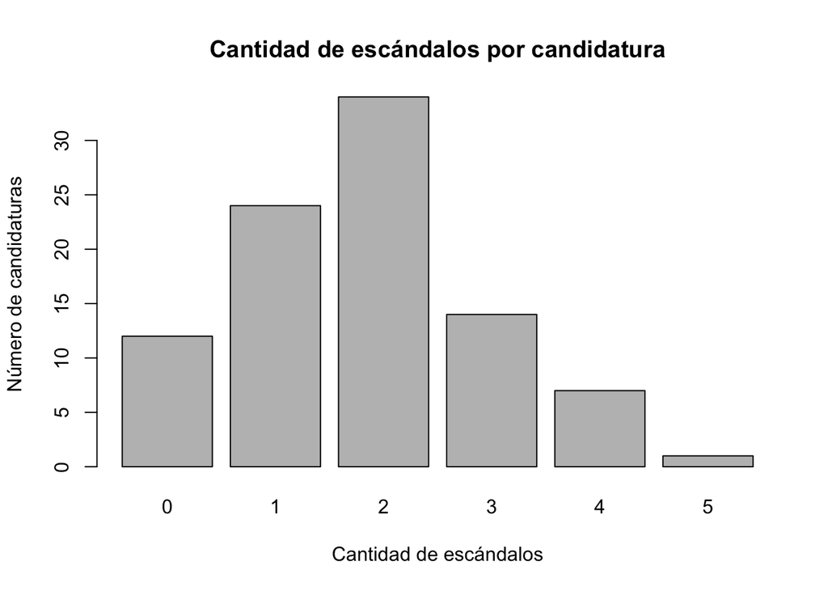

```r
#1: la cantidad de escándalos por candidatura
barplot(table(base$n_escandalos),
        main = "Cantidad de escándalos por candidatura",
        xlab = "Cantidad de escándalos",
        ylab = "Número de candidaturas")
```

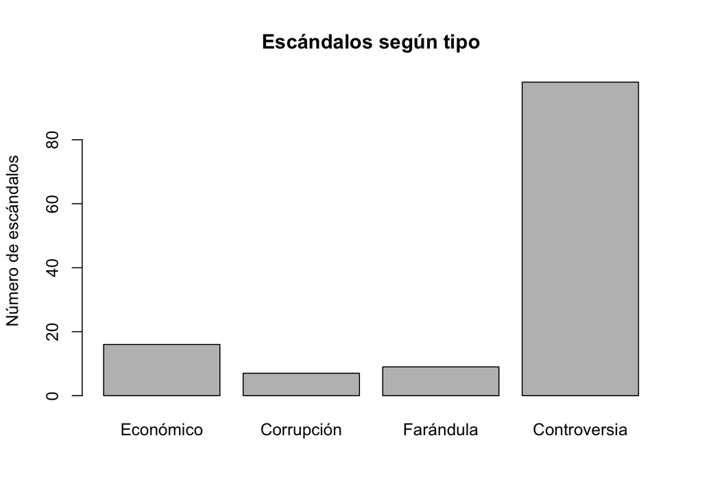

```r
#2: cuántos escandalos hubo de cada tipo
barplot(table(solo_escandalos$tipo),
        names.arg = c("Económico", "Corrupción", "Farándula", "Controversia"),
        main = "Escándalos según tipo",
        ylab = "Número de escándalos")
```

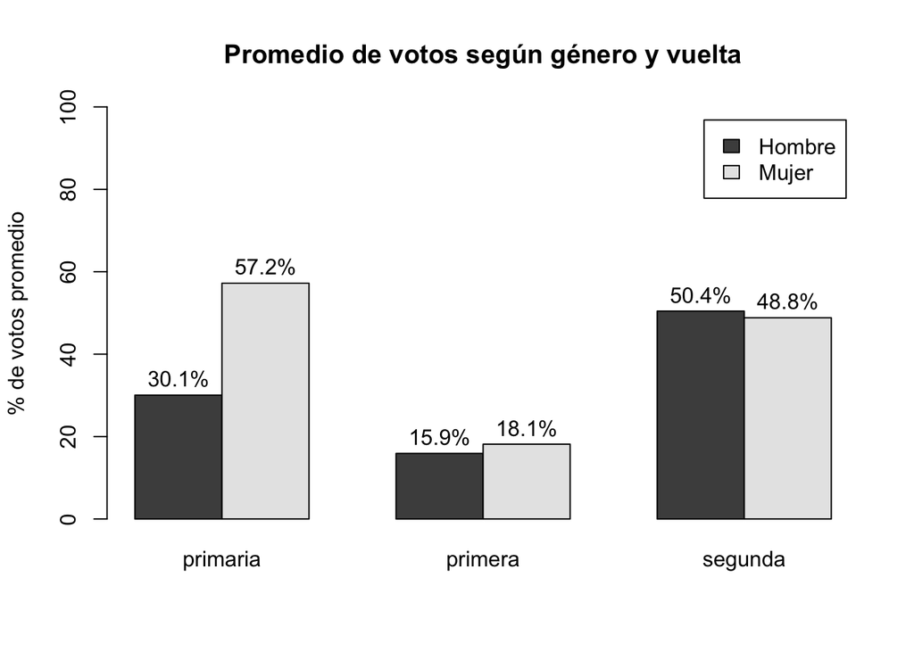

```r
#3: promedio de votos segun genero y vuelta
promedio_vuelta <- tapply(base$votos, list(base$genero, base$vuelta), mean)

posiciones <- barplot(promedio_vuelta,
                      beside = TRUE,
                      legend.text = c("Hombre", "Mujer"),
                      ylim = c(0, 100),
                      main = "Promedio de votos según género y vuelta",
                      ylab = "% de votos promedio")
text(posiciones, promedio_vuelta + 4, labels = paste0(round(promedio_vuelta, 1), "%"))
```

#Veremos los modelos ahora, primero vemos modelos lineales que explican el porcentaje de votos de cada candidatura, el 4 es de caracter multiplicativo

```r
# Modelo 1: solo variables de interes
m1_votos <- lm(votos ~ n_escandalos + genero,
               data = base)

# Modelo 2: se agregan variables politicas
m2_votos <- lm(votos ~ n_escandalos + genero + magnitud_max + ideologia + vuelta,
               data = base)

# Modelo 3: se agregan controles economicos
m3_votos <- lm(votos ~ n_escandalos + genero + magnitud_max + ideologia + vuelta + desempleo + ipc,
               data = base)

# Modelo 4: modelo multiplicativo (interacción escándalos × género)
m4_votos <- lm(votos ~ n_escandalos * genero + magnitud_max + ideologia + vuelta + desempleo + ipc,
               data = base)
```

#Aqui usamos un modelo logit condicional (clogit) que explican la probabilidad de ganar la vuelta comparando a cada candidatura solo son sus rivales de la misma carrera, strata(carrera) significa que cada candidatura se comara solo con sus rivales de la carrera.

```r
# Modelo 5: solo variables de interes
c1_gano <- clogit(gano ~ n_escandalos + genero + strata(carrera),
                  data = base)

# Modelo 6: se agregan magnitud e ideologia
c2_gano <- clogit(gano ~ n_escandalos + genero + magnitud_max + ideologia + strata(carrera),
                  data = base)

# Modelo 7: modelo multiplicativo (interacción escandalos × genero)
c3_gano <- clogit(gano ~ n_escandalos * genero + magnitud_max + ideologia + strata(carrera),
                  data = base)
```

#Asignamos nombres a las variables para las tablas y agrupamos en los modelos

```r
library(modelsummary)

cm <- c("(Intercept)" = "(Intercepto)",
        "n_escandalos" = "N° de escándalos",
        "genero" = "Mujer",
        "n_escandalos:genero" = "N° de escándalos × Mujer",
        "magnitud_max" = "Magnitud del escándalo",
        "ideologia" = "Ideología (izquierda a derecha)",
        "vueltaprimera" = "Primera vuelta",
        "vueltasegunda" = "Segunda vuelta",
        "desempleo" = "Desempleo",
        "ipc" = "IPC")
```

#Listas de modelos

```r
modelos_votos <- list("Modelo 1" = m1_votos,
                      "Modelo 2" = m2_votos,
                      "Modelo 3" = m3_votos,
                      "Modelo 4" = m4_votos)


modelos_clogit <- list("Modelo 5" = c1_gano,
                       "Modelo 6" = c2_gano,
                       "Modelo 7" = c3_gano)
```

#Guardar las tablas!!!!

```r
# Guardar la tabla de modelos lineales como HTML (para abrir en Word)
modelsummary(modelos_votos,
             gof_omit = "AIC|BIC|Log.Lik.|F|RMSE",
             coef_map = cm,
             stars = T,
             output = "output/tabla_lineales.html")

# Guardar la tabla de modelos clogit como HTML (para abrir en Word)
modelsummary(modelos_clogit,
             exponentiate = T,
             gof_omit = "AIC|BIC|Log.Lik.|F|RMSE",
             coef_map = cm,
             stars = T,
             output = "output/tabla_clogit.html")
```

```r
# Ver la tabla de modelos lineales
modelsummary(modelos_votos,
             gof_omit = "AIC|BIC|Log.Lik.|F|RMSE",
             coef_map = cm,
             stars = T)
```

|  | Modelo 1 | Modelo 2 | Modelo 3 | Modelo 4 |
| --- | --- | --- | --- | --- |
| (Intercepto) | 17.482*** | 29.939*** | 14.206 | 13.027 |
|  | (4.118) | (4.640) | (11.542) | (11.685) |
| N° de escándalos | 3.905* | 0.856 | 0.461 | -0.097 |
|  | (1.900) | (2.123) | (2.087) | (2.226) |
| Mujer | 7.337 | 8.254+ | 10.560* | 4.970 |
|  | (5.357) | (4.539) | (4.554) | (8.877) |
| N° de escándalos × Mujer |  |  |  | 2.841 |
|  |  |  |  | (3.868) |
| Magnitud del escándalo |  | 2.068 | 3.159 | 3.218 |
|  |  | (3.246) | (3.243) | (3.253) |
| Ideología (izquierda a derecha) |  | 1.665 | 1.760 | 1.688 |
|  |  | (1.107) | (1.086) | (1.093) |
| Primera vuelta |  | -18.452*** | -19.442*** | -19.240*** |
|  |  | (4.171) | (4.111) | (4.132) |
| Segunda vuelta |  | 12.032* | 12.126* | 12.172* |
|  |  | (5.826) | (5.758) | (5.774) |
| Desempleo |  |  | 1.317 | 1.534 |
|  |  |  | (1.170) | (1.210) |
| IPC |  |  | 1.070* | 1.108* |
|  |  |  | (0.483) | (0.487) |
| Num.Obs. | 92 | 92 | 92 | 92 |
| R2 | 0.071 | 0.416 | 0.452 | 0.456 |
| R2 Adj. | 0.050 | 0.375 | 0.400 | 0.396 |

+ p < 0.1, * p < 0.05, ** p < 0.01, *** p < 0.001

```r
# Ver la tabla de modelos clogit
modelsummary(modelos_clogit,
             exponentiate = T,
             gof_omit = "AIC|BIC|Log.Lik.|F|RMSE",
             coef_map = cm,
             stars = T)
```

|  | Modelo 5 | Modelo 6 | Modelo 7 |
| --- | --- | --- | --- |
| N° de escándalos | 1.264 | 0.881 | 0.777 |
|  | (0.286) | (0.275) | (0.273) |
| Mujer | 2.215 | 2.847+ | 1.178 |
|  | (1.260) | (1.755) | (1.405) |
| N° de escándalos × Mujer |  |  | 1.556 |
|  |  |  | (0.798) |
| Magnitud del escándalo |  | 1.913 | 1.981 |
|  |  | (0.852) | (0.901) |
| Ideología (izquierda a derecha) |  | 1.206 | 1.192 |
|  |  | (0.188) | (0.187) |
| Num.Obs. | 92 | 92 | 92 |

+ p < 0.1, * p < 0.05, ** p < 0.01, *** p < 0.001